# Exercise 4_2: Fancy Map

Advanced Geospatial Data Processing for Social Scientists

Author

Dennis Abel & Stefan Jünger

### Exercises

We want to create a second graph which zooms into Texas and visualizes population dynamics between 2000 and 2020.

**🏋 Exercise 1**

**🏋 Exercise 2**

In order to study population dynamics in Texas, we will calculate simple differences between 2000 and 2020 for each grid cell based on our two raster layers for Texas. Store the result in a new raster file and visualize a simple plot of it. Texas is one of the US states with the highest population increase in the last decades - this should be reflected in the map.

**🏋 Exercise 3**

**🏋 Exercise 4**

Let’s create a first plot with `ggplot`which contains the shapefile and raster file. Adjust the color scheme by utilizing `scale_fill_viridis_c`, `scale_fill_distiller`, or `scale_fill_gradient2`.

**🏋 Exercise 5**

We also want to attach labels to the top three counties by population growth. You can utilize `slice_head(n = 3)` after ordering the data in descending order to select only those three observations. Add this as an additional layer to the plot as text or text labels.

**🏋 Exercise 6**

Polish your visualization. You could: - Turn NAs transparent, - Add titles, - Adjust the overall theme of the plot, - Add North arrow and scale bar.

### Solutions

**✅ Solution 1**

```r
library(dplyr)
library(sf)
library(ggplot2)
library(terra)
library(tidyterra)
library(tigris)

# Load the raster data
TX_pop_2020 <- terra::rast("./data/US-TX_ppp_2020_1km.tif")
TX_pop_2000 <- terra::rast("./data/US-TX_ppp_2000_1km.tif")

# Load Texas county data
TX_counties <- tigris::counties("TX")

plot(st_geometry(TX_counties))
```

```
terra 1.8.29
```

[output not shown]

[output not shown]

[output cut: 6709 more lines]

[output not shown]

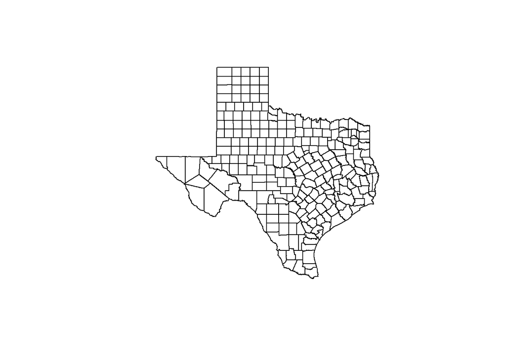

**✅ Solution 2**

```r
# Let's calculate the deviation
TX_pop_diff <- TX_pop_2020 - TX_pop_2000

TX_pop_diff
```

[output not shown]

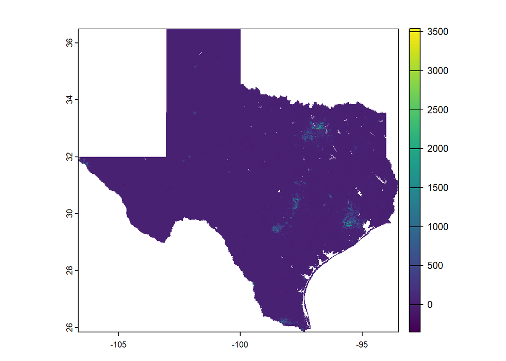

```r
terra::plot(TX_pop_diff)
```

**✅ Solution 3**

```r
TX_pop_diff <- terra::project(TX_pop_diff, "EPSG:3081")
TX_counties <- sf::st_transform(TX_counties, crs = "EPSG:3081")
```

**✅ Solution 4**

```
<SpatRaster> resampled to 500850 cells.
```

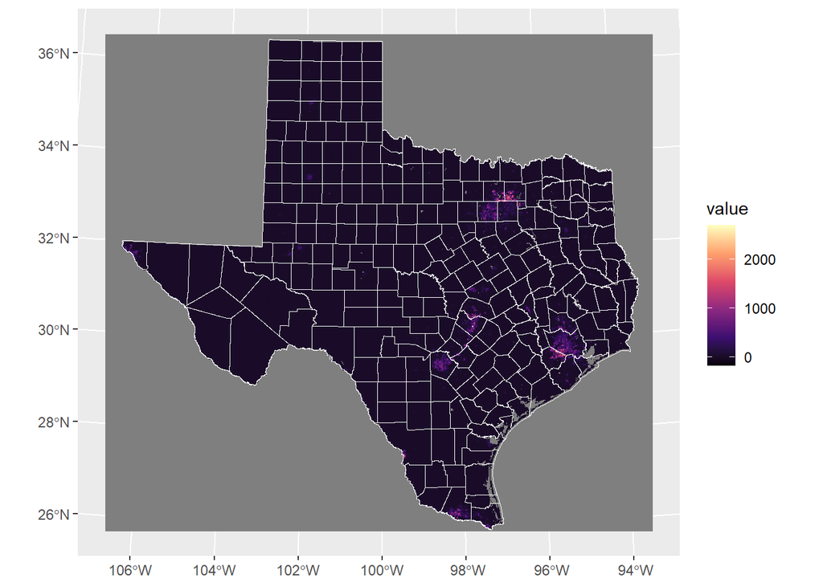

```r
# Let's adjust color palette to account for diverging values
ggplot()+
  geom_spatraster(data = TX_pop_diff)+
  geom_sf(data = TX_counties,
          fill = "transparent",
          color = "white",
          size = 3)+
  scale_fill_viridis_c(option = "magma")
```

```
<SpatRaster> resampled to 500850 cells.
```

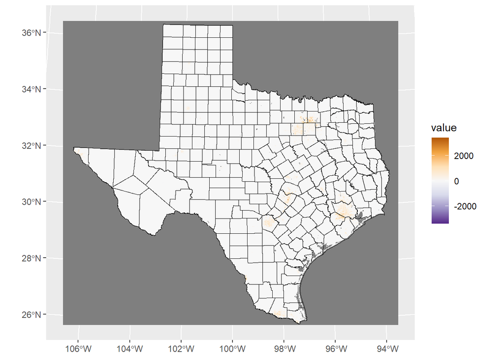

```r
# Identify max and min to adjust for skewness of positive and negative values
max_val <- max(abs(minmax(TX_pop_diff)))

ggplot()+
  geom_spatraster(data = TX_pop_diff)+
  geom_sf(data = TX_counties,
          fill = "transparent",
          color = "black",
          size = 3)+
  scale_fill_distiller(type = "div", palette = "PuOr", limits = c(-max_val, max_val))
```

```
<SpatRaster> resampled to 500850 cells.
```

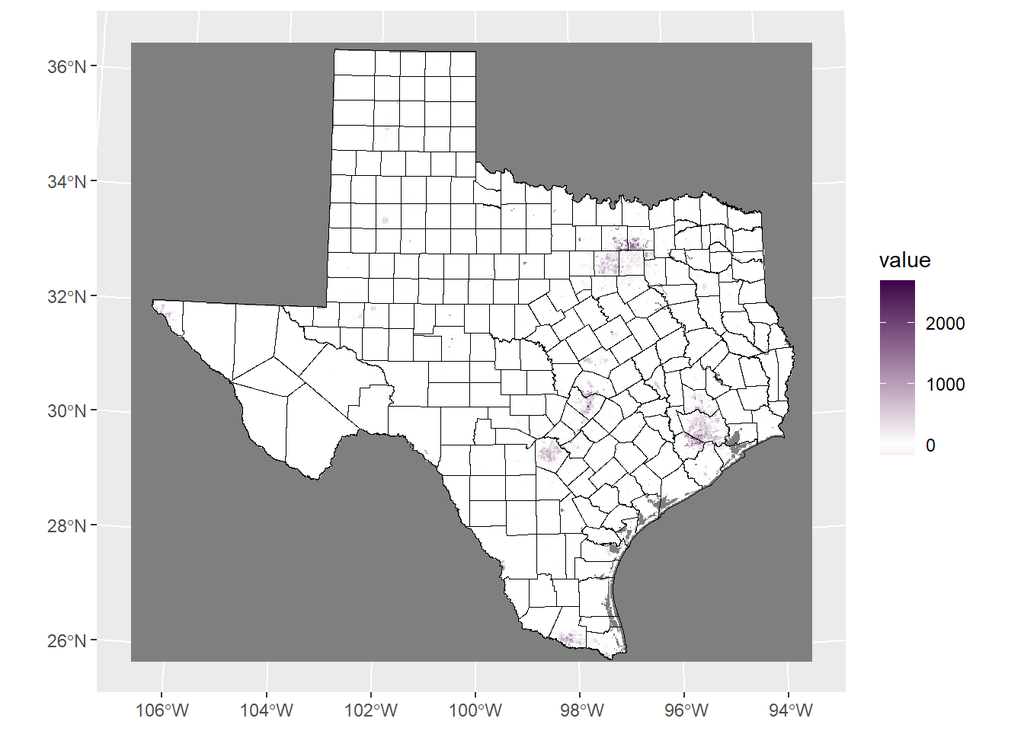

```r
# Or define manually for even greater control
ggplot()+
  geom_spatraster(data = TX_pop_diff)+
  geom_sf(data = TX_counties,
          fill = "transparent",
          color = "black",
          size = 3)+
  scale_fill_gradient2(
    low = "#7f3b08",
    mid = "white",
    high = "#40004b",
    midpoint = 0
  )
```

**✅ Solution 5**

```
<SpatRaster> resampled to 500850 cells.
```

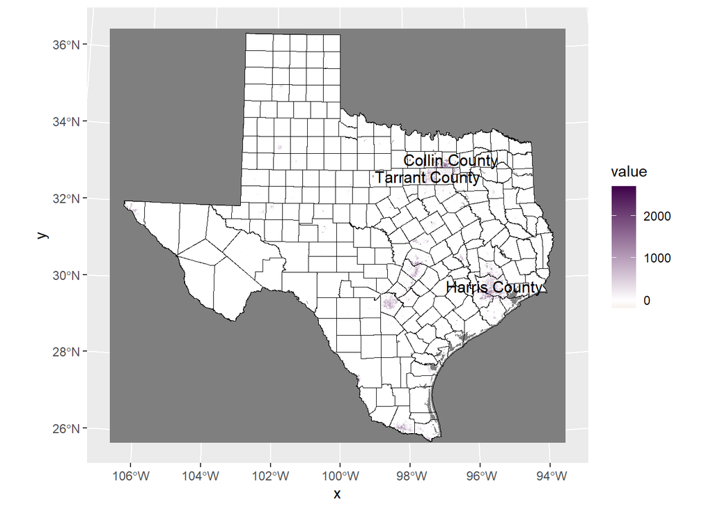

```r
# Identify growing and shrinking counties
TX_counties <- TX_pop_diff |>
  extract(TX_counties, fun = mean, na.rm =TRUE) |>
  as_tibble() %>%
  bind_cols(TX_counties, .)

# Select top three counties by population growth
extremes <- TX_counties |>
  arrange(desc(`US-TX_ppp_2020_1km`)) |>
  slice_head(n=3)

# Add geom_sf_text layer to the plot
ggplot()+
  geom_spatraster(data = TX_pop_diff)+
  geom_sf(data = TX_counties,
          fill = "transparent",
          color = "black",
          size = 3)+
  geom_sf_text(data = extremes, aes(label = NAMELSAD), size = 4, color = "black")+
  scale_fill_gradient2(
    low = "#7f3b08",
    mid = "white",
    high = "#40004b",
    midpoint = 0
  )
```

**✅ Solution 6**

```
<SpatRaster> resampled to 500850 cells.
```

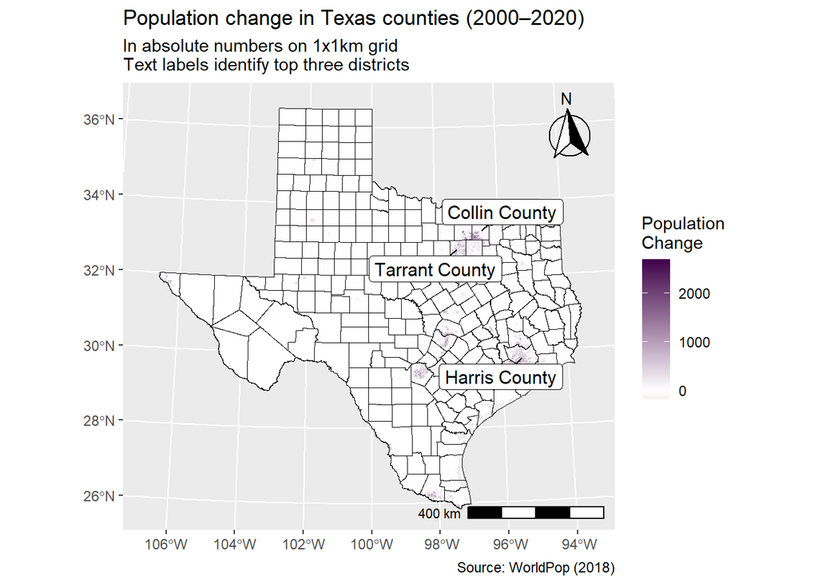

```r
# Final polishing
library(ggspatial)
library(ggrepel)

ggplot()+
  geom_spatraster(data = TX_pop_diff)+
  geom_sf(data = TX_counties,
          fill = "transparent",
          color = "black",
          size = 3)+
  geom_label_repel(
    data = extremes,
    aes(geometry = geometry, label = NAMELSAD),
    stat = "sf_coordinates",
    min.segment.length = 0,
    segment.color = "black",
    segment.size = 0.5,
    size = 4,
    fill = "white",
    color = "black",
    label.size = 0.2
  )+
  scale_fill_gradient2(
    low = "#7f3b08",
    mid = "white",
    high = "#40004b",
    midpoint = 0,
    na.value = "transparent",
    name = "Population\nChange"
  )+
  theme_grey()+
  theme(
    axis.title = element_blank()
  ) +
  labs(
    title = "Population change in Texas counties (2000–2020)",
    subtitle = "In absolute numbers on 1x1km grid\nText labels identify top three districts",
    caption = "Source: WorldPop (2018)"
  ) +
  annotation_scale(
    location = "br",
    width_hint = 0.3
  ) +
  annotation_north_arrow(
    location = "tr",
    which_north = "true",
    style = north_arrow_fancy_orienteering
  )
```